# PML Course Project

SunjayM

August 5, 2016

# Practical Machine Learning Project: Measurements of Accelerometer Data

### Background

Using devices such as Jawbone Up, Nike FuelBand, and Fitbit it is now possible to collect a large amount of data about personal activity relatively inexpensively. These type of devices are part of the quantified self movement - a group of enthusiasts who take measurements about themselves regularly to improve their health, to find patterns in their behavior, or because they are tech geeks. One thing that people regularly do is quantify how much of a particular activity they do, but they rarely quantify how well they do it. In this project, your goal will be to use data from accelerometers on the belt, forearm, arm, and dumbell of 6 participants. They were asked to perform barbell lifts correctly and incorrectly in 5 different ways. More information is available from the website here: http://groupware.les.inf.puc-rio.br/har (see the section on the Weight Lifting Exercise Dataset).

### Source of Data and Credit

Data The training data for this project are available here: https://d396qusza40orc.cloudfront.net/predmachlearn/pml-training.csv

The test data are available here: https://d396qusza40orc.cloudfront.net/predmachlearn/pml-testing.csv

###### Credit/ Resources

The data for this project come from this source: http://groupware.les.inf.puc-rio.br/har

### Executive Summary of Analysis

In this project we will attempt to predict the data points provideded from the links above directing us to a training and test datasets.

Our initial step will be to load the necessary packages required for this particular analysis.

Our second step will be to read the data into RStudio and understand the data with an initial exploratory analysis. Next we will split the training data set into a 60:40 ratio of Training and validation data respectively. Once the data is partitioned, look for any NA values or anomolies and clean to create a more transparent analysis.

Next we need to implement the various machine learning algorithms to our partioned testing dataset. The various algorithms that we will run are the Decision Tree, Random Forest, and Support Machine Vector models to predict the best method.

Once the algorithms have been implemented, we need to scrutnize the various metrics for performance and accuracy. Lastly we will isolate the algorithm with the higest accuracy to systematically predict the test dataset provided.

#### Packages to Load for Analysis

```r
set.seed(21191)

library(RGtk2) #For the Libatk library being used in Rattle
library(ggplot2)
library(dplyr)
library(caret)
library(rpart)
library(rpart.plot)
library(rattle)
library(randomForest)
library(e1071)
```

#### Loading Data

Extract the data from the working directory which has the data from the URLs provided above

```r
setwd("~/R/Data Sets/Practical Machine Learning")

training<-read.csv("TrainingSet.csv", sep = ",", header = TRUE)
testing<-read.csv("TestingSet1.csv", sep = ",", header = TRUE)
```

#### Partioning of Data to Test and Train sets to create model and check its accuracy

Partition the training data into 60% training and 40% validation set and check dimensions to verify partition occured as designed.

```r
inTrain <- createDataPartition(y=training$classe, p=0.6, list=FALSE)
mydataTrain <- training[inTrain, ];
mydataTest <- training[-inTrain, ]
```

Verify the dimensions of the new datasets created by partioning the training dataset

```r
dim(mydataTrain)
```

```
## [1] 11776   160
```

```r
dim(mydataTest)
```

```
## [1] 7846  160
```

#### Cleaning Data for Analysis

The two sets created by partitioning the data are the same since they both returned with 160 variables. Sifting through the set further, you’ll notice there are NA values in the sets and need to be removed. Therefore we are creating a new dataset removing the NAs from the Test and Training datasets where 90% of the columns are populated with null values.

```r
mydataTrain <- mydataTrain[, colMeans(is.na(mydataTrain)) < 0.1]
mydataTest <- mydataTest[, colMeans(is.na(mydataTest)) < 0.1]
```

New Train and Test datasets can be checked again to determine any changes in new datasets.

```r
dim(mydataTrain)
```

```
## [1] 11776    93
```

```r
dim(mydataTest)
```

```
## [1] 7846   93
```

```r
head(mydataTrain[1:15])
```

```
##   X user_name raw_timestamp_part_1 raw_timestamp_part_2  cvtd_timestamp
## 2 2  carlitos           1323084231               808298 5/12/2011 11:23
## 3 3  carlitos           1323084231               820366 5/12/2011 11:23
## 4 4  carlitos           1323084232               120339 5/12/2011 11:23
## 5 5  carlitos           1323084232               196328 5/12/2011 11:23
## 6 6  carlitos           1323084232               304277 5/12/2011 11:23
## 7 7  carlitos           1323084232               368296 5/12/2011 11:23
##   new_window num_window roll_belt pitch_belt yaw_belt total_accel_belt
## 2         no         11      1.41       8.07    -94.4                3
## 3         no         11      1.42       8.07    -94.4                3
## 4         no         12      1.48       8.05    -94.4                3
## 5         no         12      1.48       8.07    -94.4                3
## 6         no         12      1.45       8.06    -94.4                3
## 7         no         12      1.42       8.09    -94.4                3
##   kurtosis_roll_belt kurtosis_picth_belt kurtosis_yaw_belt
## 2
## 3
## 4
## 5
## 6
## 7
##   skewness_roll_belt
## 2
## 3
## 4
## 5
## 6
## 7
```

Furthermore we can remove the first five columns which are ID columns, and timestamps that we do not need for this particular analysis.

```r
mydataTrain <- mydataTrain[, -(1:5)]
mydataTest <- mydataTest[, -(1:5)]

dim(mydataTrain)
```

```
## [1] 11776    88
```

```r
dim(mydataTest)
```

```
## [1] 7846   88
```

Looking further into the dataset, we notice there are variables with zerovariance and should be removed to create more lucid models.

```r
close.2.zero <- nearZeroVar(mydataTrain)
mydataTrain <- mydataTrain[, -close.2.zero]
mydataTest <- mydataTest[, -close.2.zero]

dim(mydataTrain)
```

```
## [1] 11776    54
```

```r
dim(mydataTest)
```

```
## [1] 7846   54
```

We have reduced the number of variables from 160 initially to 54 after multiple iterations to clean the dataset. Since both the mydataTest and mydataTrain have an equal number of variables, we can implement our prediction algorithms in an easier fashion.

==========

# Prediction Algorithms

Noe that we have cleaned up the data we will test and validate, we can go ahead and implement into the different algorithms to create the best predicint model.

We will explore three distinct machine learning algorithms: 1.) Decision Tree (rpart) 2.) Random Forest (randomForest) 3.) Support Machine Vector (svm)

#### 1. Decision Tree (rpart)

```r
train.dt.model <- train(classe ~ ., method = "rpart", data = mydataTrain)
predict.dt.model <- predict(train.dt.model, mydataTest)
cm.dt <- confusionMatrix(predict.dt.model, mydataTest$classe)
print(train.dt.model$finalModel)
```

```
## n= 11776
##
## node), split, n, loss, yval, (yprob)
##       * denotes terminal node
##
##  1) root 11776 8428 A (0.28 0.19 0.17 0.16 0.18)
##    2) roll_belt< 130.5 10795 7457 A (0.31 0.21 0.19 0.18 0.11)
##      4) pitch_forearm< -33.95 990    7 A (0.99 0.0071 0 0 0) *
##      5) pitch_forearm>=-33.95 9805 7450 A (0.24 0.23 0.21 0.2 0.12)
##       10) magnet_dumbbell_y< 439.5 8281 5972 A (0.28 0.18 0.24 0.19 0.11)
##         20) roll_forearm< 123.5 5118 3048 A (0.4 0.18 0.18 0.17 0.059) *
##         21) roll_forearm>=123.5 3163 2112 C (0.076 0.18 0.33 0.23 0.19) *
##       11) magnet_dumbbell_y>=439.5 1524  749 B (0.03 0.51 0.043 0.22 0.2) *
##    3) roll_belt>=130.5 981   10 E (0.01 0 0 0 0.99) *
```

[figure not shown]

```r
fancyRpartPlot(train.dt.model$finalModel,cex=.5,under.cex=1,shadow.offset=0)
```

#### 2. Random Forest

```r
train.rf.model <- randomForest(classe ~ ., data = mydataTrain, mtry = 3, ntree = 200, do.trace = 25, cv.fold = 10)
```

```
## ntree      OOB      1      2      3      4      5
##    25:   1.65%  0.69%  2.59%  1.90%  2.49%  1.15%
##    50:   0.77%  0.15%  1.01%  1.02%  1.71%  0.42%
##    75:   0.67%  0.12%  0.79%  1.12%  1.40%  0.32%
##   100:   0.61%  0.09%  0.57%  0.88%  1.55%  0.37%
##   125:   0.65%  0.12%  0.53%  0.97%  1.61%  0.42%
##   150:   0.60%  0.09%  0.57%  0.83%  1.61%  0.32%
##   175:   0.54%  0.06%  0.44%  0.83%  1.45%  0.32%
##   200:   0.53%  0.06%  0.44%  0.78%  1.40%  0.32%
```

```r
Predict.rf.model <- predict(train.rf.model, mydataTest)
cm.rf <- confusionMatrix(Predict.rf.model, mydataTest$classe)
```

#### Variable Importance According to Random Forest

```r
imp.rf <- importance(train.rf.model)
imp.rf.arranged <- arrange(as.data.frame(imp.rf), desc(MeanDecreaseGini))

head(imp.rf.arranged, 15)
```

```
##    MeanDecreaseGini
## 1          507.0728
## 2          504.7364
## 3          379.8440
## 4          351.1914
## 5          342.7266
## 6          318.9453
## 7          302.5428
## 8          266.5286
## 9          260.5889
## 10         248.6737
## 11         242.3576
## 12         238.2436
## 13         227.5639
## 14         206.7479
## 15         203.5785
```

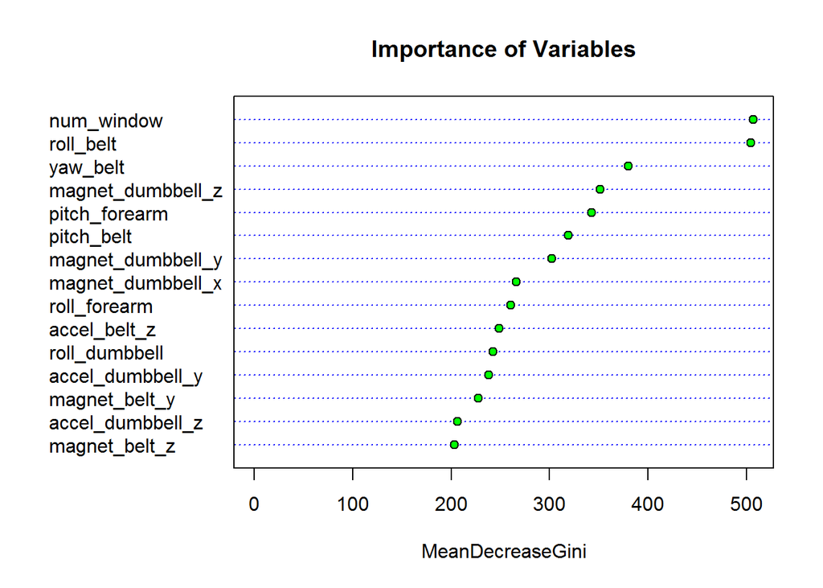

```r
varImpPlot(train.rf.model, n.var = 15, sort = TRUE, main = "Importance of Variables", lcolor = "blue", bg = "green")
```

Using Random Forest we can find the importance of each variable independently from others.

#### 3. Support Vector Machine

```r
train.svm.model <- svm(classe ~ ., data = mydataTrain)
predict.svm.model <- predict(train.svm.model, mydataTest)
cm.svm <- confusionMatrix(predict.svm.model, mydataTest$classe)
```

##### Compare Accuracies

```r
decisiontree <- cm.dt$overall[1]
RndForest <- cm.rf$overall[1]
SupVecMach <- cm.svm$overall[1]

cm.dataframe <- data.frame(Algorithm = c("Decision Tree", "Random Forest", "Support Vector Machine"), Index = c("dt", "rf", "svm"), Accuracy = c(decisiontree, RndForest, SupVecMach))
cm.dataframe <- arrange(cm.dataframe, desc(Accuracy))
cm.dataframe
```

```
##                Algorithm Index  Accuracy
## 1          Random Forest    rf 0.9949019
## 2 Support Vector Machine   svm 0.9417538
## 3          Decision Tree    dt 0.4937548
```

We can clearly see that Random Forest has the highest accuracy at ~ 99.5%, followed by Support Vector Machine at ~ 94.2%. Decision Tree gave us the lowest accuracy at ~ 49.4%.

#### Errors

*Calculate the In Sample Error

```r
InSampError.rf <- (1 - 0.994)*100
InSampError.rf
```

```
## [1] 0.6
```

*Calculate the Out of Sample Error

```r
print(train.rf.model)
```

```
##
## Call:
##  randomForest(formula = classe ~ ., data = mydataTrain, mtry = 3,      ntree = 200, do.trace = 25, cv.fold = 10)
##                Type of random forest: classification
##                      Number of trees: 200
## No. of variables tried at each split: 3
##
##         OOB estimate of  error rate: 0.53%
## Confusion matrix:
##      A    B    C    D    E  class.error
## A 3346    2    0    0    0 0.0005973716
## B    9 2269    1    0    0 0.0043878894
## C    0   16 2038    0    0 0.0077896787
## D    0    0   26 1903    1 0.0139896373
## E    0    0    0    7 2158 0.0032332564
```

However, it is worthy to note that Random Forest Out of Bag estimation does not require Cross Validation to decrease bias.

#### Final Prediction Using Random Forest

Prediction Results of Algorithm with Highest Accuracy (Random Forest)

```r
fp.rf <- predict(train.rf.model, newdata=testing)
fp.rf
```

```
##  1  2  3  4  5  6  7  8  9 10 11 12 13 14 15 16 17 18 19 20
##  B  A  B  A  A  E  D  B  A  A  B  C  B  A  E  E  A  B  B  B
## Levels: A B C D E
```